# IPI

# 1 Load required packages

```r
library("tidyr")
library("dplyr")
```

```r
library("stringr")
library("visreg")
library("ggplot2")
library("mgcv")
library("itsadug")
library("plyr")
```

# 2 Introduction

From the c-center hypothesis it follows that onsets are coordinated inphase with the following vowel, meaning that they are initiated roughly around the same time. On the other hand, multiple consonants in an onset are also coordinated antiphase with each other (i.e. sequential initiation). To cope with these competing relations, the leftmost C gets shifted towards the left and the rightmost C gets shifted towards the right (with respect to the following vowel) in complex onsets. In this way, the average onset of the two C’s is still initiated at the same time as the vowel, whereas they are also still coordinated in an antiphase relation with each other. Our hypothesis is that PD patients will show a stronger preference for the inphase relationship, coming at the cost of the antiphase relationship. In our data we’ve included three singular onsets /p/, /m/ and /x/ and four complex onsets: /sp/, /sm/, /sx/ and /spr/. The variable ‘time.lag.norm’ is the normalized time lag between the offset of the leftmost C and the onset of the rightmost C. If our hypothesis is correct the lag between the C’s should be lower for the PD group in comparison with the controls.

## 2.1 Read data

```r
df <- readRDS("C:/Users/Jidde/Desktop/analysis/data/modelling_data_CC.rds")
```

## 2.2 Clean data

Remove all the rows that have NA in the dependent variable and drop ‘empty’ levels, convert variables to factors and create trimmed dataset.

```r
df$subj <- as.factor(df$subj)

df <- df[complete.cases(df$time.lag.norm),]
df <- droplevels(df)

# Sort data
df <- df[order(df$subj, df$recording.no),]

# convert to factors/numeric
df$prompt <- as.factor(df$prompt)
df$condition <- as.factor(df$condition)

# remove all the recordings without a speech rate measure:
# df <- df %>% drop_na(duration.tt)

# remove participants with only a few datapoints
#remove <- c("PD19", "CTRL19")
#df.trim <- df[! df$subj %in% remove, ]
#df.trim <- droplevels(df.trim)


# create df without sx
#df.trim <- df.trim[! df.trim$cluster == "sx", ]
#df.trim <- droplevels(df.trim)
#levels(df.trim$cluster)

df$group <- revalue(df$group, c("CTRL"="typical"))
df$group<- relevel(df$group, ref = "PD")

# create df without spr
df.nospr <- df[! df$cluster == "spr", ]
df.nospr <- droplevels(df.nospr)
levels(df.nospr$cluster)
```

```
## [1] "sm" "sp" "sx"
```

```r
df.nospr$cluster <- relevel(df.nospr$cluster, ref = "sm")

df.nospr$condition <- recode_factor(df.nospr$condition, C = "singleton",
                                CC = "cluster")

df.nospr$condition <- recode_factor(df.nospr$condition, male = "male",
                                    female = "female")



# merge /sm/ and /sp/
df.nospr$poa <- ifelse(df.nospr$cluster == "sx","C2lingual","C2bilabial")
df.nospr$poa <- as.factor(df.nospr$poa)
table(df.nospr$poa, df.nospr$cluster)
```

```
##
##               sm  sp  sx
##   C2bilabial 406 432   0
##   C2lingual    0   0 300
```

Create ordered factors:

```r
df.nospr$group.ord <- as.ordered(df.nospr$group)
contrasts(df.nospr$group.ord) <- "contr.treatment"

df.nospr$cluster.ord <- as.ordered(df.nospr$cluster)
contrasts(df.nospr$cluster.ord) <- "contr.treatment"

df.nospr$gender.ord <- as.ordered(df.nospr$gender)
contrasts(df.nospr$gender.ord) <- "contr.treatment"
```

Create binary dummy variables:

```r
df.nospr$IsTP <- (df.nospr$group == "typical")*1
```

## 2.3 Plot data

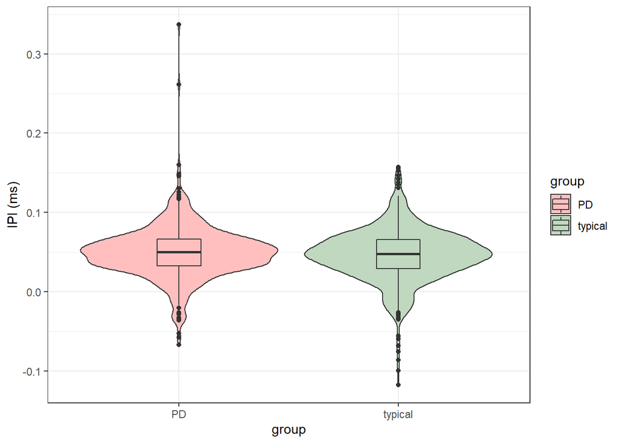

```r
ggplot(df.nospr, aes(x=group, y=time.lag.norm, fill=group))  + geom_violin() + geom_boxplot(width=.2) + labs(y = "IPI (ms)") +  scale_fill_manual(values=c("#ffbfbf", "#bfd8bf")) + theme_bw()
```

# 3 GAM models for CC lag analysis (coarticulation)

If indeed patients would show a stronger preference for inphase coordination, this would mean that they would produce the C gestures in the syllable’s onset closer together in time. For this, we look at the lag between the gestural offset of the leftmost C and the gestural onset of the righmost C in complex clusters.

## 3.1 Hypothesis testing

Creat base model:

```r
summary(mbase <- bam(time.lag.norm ~ s(subj,bs='re'), data=df.nospr))
```

```
##
## Family: gaussian
## Link function: identity
##
## Formula:
## time.lag.norm ~ s(subj, bs = "re")
##
## Parametric coefficients:
##             Estimate Std. Error t value Pr(>|t|)
## (Intercept) 0.047826   0.001948   24.55   <2e-16 ***
## ---
## Signif. codes:  0 '***' 0.001 '**' 0.01 '*' 0.05 '.' 0.1 ' ' 1
##
## Approximate significance of smooth terms:
##           edf Ref.df     F p-value
## s(subj) 34.12     46 3.089  <2e-16 ***
## ---
## Signif. codes:  0 '***' 0.001 '**' 0.01 '*' 0.05 '.' 0.1 ' ' 1
##
## R-sq.(adj) =  0.111   Deviance explained = 13.8%
## fREML = -2259.6  Scale est. = 0.0010334  n = 1138
```

Adding group as fixed effect:

```r
summary(mhypo <- bam(time.lag.norm ~ group + s(subj,bs='re'), data=df.nospr))
```

```
##
## Family: gaussian
## Link function: identity
##
## Formula:
## time.lag.norm ~ group + s(subj, bs = "re")
##
## Parametric coefficients:
##               Estimate Std. Error t value Pr(>|t|)
## (Intercept)   0.049597   0.002806  17.674   <2e-16 ***
## grouptypical -0.003424   0.003901  -0.878     0.38
## ---
## Signif. codes:  0 '***' 0.001 '**' 0.01 '*' 0.05 '.' 0.1 ' ' 1
##
## Approximate significance of smooth terms:
##           edf Ref.df     F p-value
## s(subj) 33.38     45 3.086  <2e-16 ***
## ---
## Signif. codes:  0 '***' 0.001 '**' 0.01 '*' 0.05 '.' 0.1 ' ' 1
##
## R-sq.(adj) =  0.111   Deviance explained = 13.8%
## fREML = -2255.3  Scale est. = 0.0010336  n = 1138
```

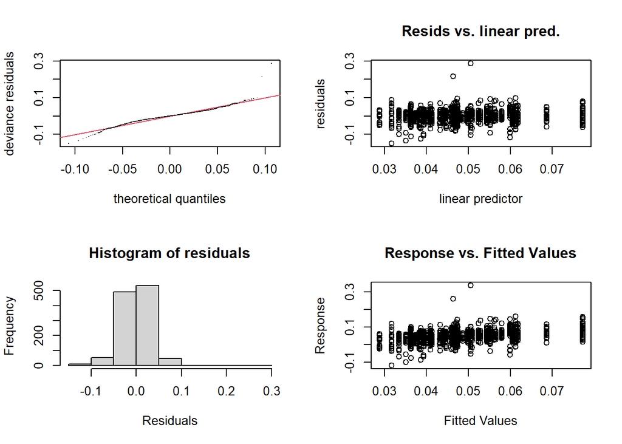

```
##
## Method: fREML   Optimizer: perf newton
## full convergence after 7 iterations.
## Gradient range [-1.952219e-08,-5.582379e-10]
## (score -2255.344 & scale 0.001033584).
## Hessian positive definite, eigenvalue range [11.97966,568.5009].
## Model rank =  49 / 49
##
## Basis dimension (k) checking results. Low p-value (k-index<1) may
## indicate that k is too low, especially if edf is close to k'.
##
##           k'  edf k-index p-value
## s(subj) 47.0 33.4      NA      NA
```

```r
gam.check(mhypo)
```

Looks a bit off.

Fit with scat:

```r
summary(mhypo_scat <- bam(time.lag.norm ~ group + s(subj,bs='re'), data=df.nospr, family = "scat", discrete = T))
```

```
##
## Family: Scaled t(3.102,0.02)
## Link function: identity
##
## Formula:
## time.lag.norm ~ group + s(subj, bs = "re")
##
## Parametric coefficients:
##               Estimate Std. Error t value Pr(>|t|)
## (Intercept)   0.049493   0.002738  18.079   <2e-16 ***
## grouptypical -0.001410   0.003826  -0.368    0.713
## ---
## Signif. codes:  0 '***' 0.001 '**' 0.01 '*' 0.05 '.' 0.1 ' ' 1
##
## Approximate significance of smooth terms:
##           edf Ref.df     F p-value
## s(subj) 36.95     45 175.1  0.0298 *
## ---
## Signif. codes:  0 '***' 0.001 '**' 0.01 '*' 0.05 '.' 0.1 ' ' 1
##
## R-sq.(adj) =  0.0941   Deviance explained = 11.9%
## fREML = 1985.4  Scale est. = 1         n = 1138
```

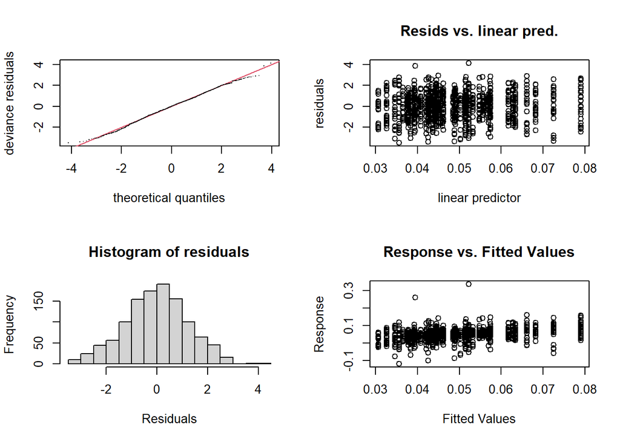

```
##
## Method: fREML   Optimizer: perf chol
## $grad
## [1] 1.28158e-07
##
## $hess
##        [,1]
## [1,] 13.903
##
## Model rank =  49 / 49
##
## Basis dimension (k) checking results. Low p-value (k-index<1) may
## indicate that k is too low, especially if edf is close to k'.
##
##           k'  edf k-index p-value
## s(subj) 47.0 36.9      NA      NA
```

```r
gam.check(mhypo_scat)
```

Better.

```r
summary(mbase_scat <- bam(time.lag.norm ~ s(subj,bs='re'), method = "ML", data=df.nospr))
```

```
##
## Family: gaussian
## Link function: identity
##
## Formula:
## time.lag.norm ~ s(subj, bs = "re")
##
## Parametric coefficients:
##             Estimate Std. Error t value Pr(>|t|)
## (Intercept) 0.047829   0.001927   24.82   <2e-16 ***
## ---
## Signif. codes:  0 '***' 0.001 '**' 0.01 '*' 0.05 '.' 0.1 ' ' 1
##
## Approximate significance of smooth terms:
##           edf Ref.df     F p-value
## s(subj) 33.87     46 3.067  <2e-16 ***
## ---
## Signif. codes:  0 '***' 0.001 '**' 0.01 '*' 0.05 '.' 0.1 ' ' 1
##
## R-sq.(adj) =  0.111   Deviance explained = 13.7%
## -ML = -2264.9  Scale est. = 0.0010337  n = 1138
```

```r
summary(mhypo_scatML <- bam(time.lag.norm ~ group + s(subj,bs='re'), method = "ML", data=df.nospr))
```

```
##
## Family: gaussian
## Link function: identity
##
## Formula:
## time.lag.norm ~ group + s(subj, bs = "re")
##
## Parametric coefficients:
##               Estimate Std. Error t value Pr(>|t|)
## (Intercept)   0.049613   0.002745  18.071   <2e-16 ***
## grouptypical -0.003441   0.003816  -0.902    0.367
## ---
## Signif. codes:  0 '***' 0.001 '**' 0.01 '*' 0.05 '.' 0.1 ' ' 1
##
## Approximate significance of smooth terms:
##           edf Ref.df    F p-value
## s(subj) 32.88     45 3.04  <2e-16 ***
## ---
## Signif. codes:  0 '***' 0.001 '**' 0.01 '*' 0.05 '.' 0.1 ' ' 1
##
## R-sq.(adj) =  0.111   Deviance explained = 13.7%
## -ML = -2265.3  Scale est. = 0.0010341  n = 1138
```

```r
compareML(mbase_scat, mhypo_scatML)
```

```
## mbase_scat: time.lag.norm ~ s(subj, bs = "re")
##
## mhypo_scatML: time.lag.norm ~ group + s(subj, bs = "re")
```

```
##
## Chi-square test of ML scores
## -----
##          Model     Score Edf Difference    Df p.value Sig.
## 1   mbase_scat -2264.913   2
## 2 mhypo_scatML -2265.315   3      0.401 1.000   0.370
##
## AIC difference: -0.51, model mbase_scat has lower AIC.
```

No improv, AIC diff is -0.51.

Model criticism, trimming:

```r
df.nospr2 <- df.nospr[abs(scale(resid(mhypo_scat))) < 2.5, ] # trim model
(1 - (nrow(df.nospr2))/nrow(df.nospr)) * 100
```

```
## [1] 0.6151142
```

0.6% removed.

Refit:

```r
summary(mhypo_scat_trim <- bam(time.lag.norm ~ group + s(subj,bs='re'), data=df.nospr2, family = "scat", discrete = T))
```

```
##
## Family: Scaled t(3.96,0.021)
## Link function: identity
##
## Formula:
## time.lag.norm ~ group + s(subj, bs = "re")
##
## Parametric coefficients:
##               Estimate Std. Error t value Pr(>|t|)
## (Intercept)   0.049511   0.002729  18.142   <2e-16 ***
## grouptypical -0.001429   0.003809  -0.375    0.708
## ---
## Signif. codes:  0 '***' 0.001 '**' 0.01 '*' 0.05 '.' 0.1 ' ' 1
##
## Approximate significance of smooth terms:
##           edf Ref.df     F p-value
## s(subj) 36.83     45 228.5  0.0463 *
## ---
## Signif. codes:  0 '***' 0.001 '**' 0.01 '*' 0.05 '.' 0.1 ' ' 1
##
## R-sq.(adj) =  0.124   Deviance explained = 12.9%
## fREML = 1905.1  Scale est. = 1         n = 1131
```

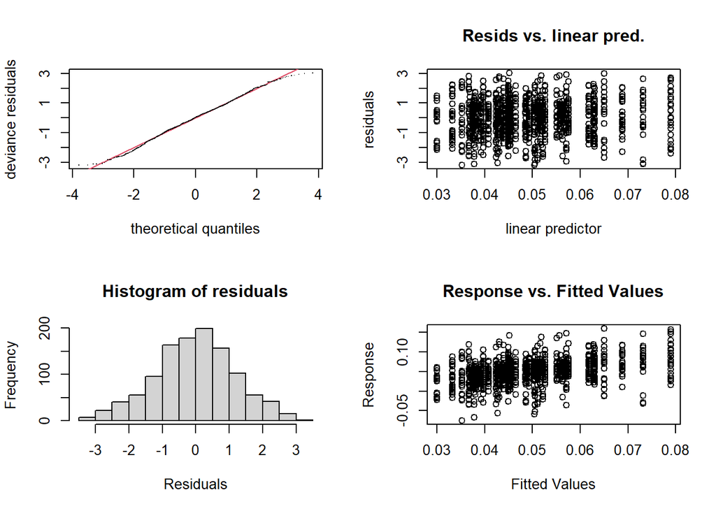

```
##
## Method: fREML   Optimizer: perf chol
## $grad
## [1] 6.112215e-08
##
## $hess
##          [,1]
## [1,] 14.04057
##
## Model rank =  49 / 49
##
## Basis dimension (k) checking results. Low p-value (k-index<1) may
## indicate that k is too low, especially if edf is close to k'.
##
##           k'  edf k-index p-value
## s(subj) 47.0 36.8      NA      NA
```

```r
gam.check(mhypo_scat_trim)
```

OK.

## 3.2 Exploratory analysis

Adding cluster as fixed effect:

```r
summary(ex1 <- bam(time.lag.norm ~ group + s(subj,bs='re'), data=df.nospr, method = "ML", family = "scat"))
```

```
##
## Family: Scaled t(3.108,0.02)
## Link function: identity
##
## Formula:
## time.lag.norm ~ group + s(subj, bs = "re")
##
## Parametric coefficients:
##               Estimate Std. Error t value Pr(>|t|)
## (Intercept)   0.049505   0.002643  18.734   <2e-16 ***
## grouptypical -0.001413   0.003676  -0.384    0.701
## ---
## Signif. codes:  0 '***' 0.001 '**' 0.01 '*' 0.05 '.' 0.1 ' ' 1
##
## Approximate significance of smooth terms:
##           edf Ref.df     F p-value
## s(subj) 36.99     45 5.288  <2e-16 ***
## ---
## Signif. codes:  0 '***' 0.001 '**' 0.01 '*' 0.05 '.' 0.1 ' ' 1
##
## R-sq.(adj) =  0.0936   Deviance explained = 11.9%
## -ML =   1666  Scale est. = 1         n = 1138
```

```r
summary(ex2 <- bam(time.lag.norm ~ group + cluster + s(subj,bs='re'), data=df.nospr, method = "ML", family = "scat"))
```

```
##
## Family: Scaled t(3,0.018)
## Link function: identity
##
## Formula:
## time.lag.norm ~ group + cluster + s(subj, bs = "re")
##
## Parametric coefficients:
##               Estimate Std. Error t value Pr(>|t|)
## (Intercept)   0.060292   0.002656  22.699   <2e-16 ***
## grouptypical -0.002376   0.003462  -0.686    0.493
## clustersp    -0.013213   0.001569  -8.420   <2e-16 ***
## clustersx    -0.027973   0.001753 -15.957   <2e-16 ***
## ---
## Signif. codes:  0 '***' 0.001 '**' 0.01 '*' 0.05 '.' 0.1 ' ' 1
##
## Approximate significance of smooth terms:
##           edf Ref.df     F p-value
## s(subj) 37.47     45 5.675  <2e-16 ***
## ---
## Signif. codes:  0 '***' 0.001 '**' 0.01 '*' 0.05 '.' 0.1 ' ' 1
##
## R-sq.(adj) =  0.201   Deviance explained = 20.5%
## -ML = 1663.8  Scale est. = 1         n = 1138
```

```r
compareML(ex1,ex2)
```

```
## ex1: time.lag.norm ~ group + s(subj, bs = "re")
##
## ex2: time.lag.norm ~ group + cluster + s(subj, bs = "re")
```

```
##
## Chi-square test of ML scores
## -----
##   Model    Score Edf Difference    Df p.value Sig.
## 1   ex1 1666.031   3
## 2   ex2 1663.834   5      2.197 2.000   0.111
##
## AIC difference: 181.43, model ex2 has lower AIC.
```

Improves: AIC difference: 181.43.

Add random slopes for cluster:

```r
summary(ex3 <- bam(time.lag.norm ~ group + cluster + s(subj,bs='re') + s(subj, cluster, bs ="re"), data=df.nospr, family = "scat"))
```

```
##
## Family: Scaled t(3,0.014)
## Link function: identity
##
## Formula:
## time.lag.norm ~ group + cluster + s(subj, bs = "re") + s(subj,
##     cluster, bs = "re")
##
## Parametric coefficients:
##               Estimate Std. Error t value Pr(>|t|)
## (Intercept)   0.061637   0.004074  15.130  < 2e-16 ***
## grouptypical -0.003794   0.004124  -0.920  0.35773
## clustersp    -0.014482   0.004807  -3.013  0.00266 **
## clustersx    -0.030495   0.004939  -6.174 9.63e-10 ***
## ---
## Signif. codes:  0 '***' 0.001 '**' 0.01 '*' 0.05 '.' 0.1 ' ' 1
##
## Approximate significance of smooth terms:
##                    edf Ref.df      F p-value
## s(subj)           2.83     45  1.265   0.378
## s(subj,cluster) 120.64    133 15.760  <2e-16 ***
## ---
## Signif. codes:  0 '***' 0.001 '**' 0.01 '*' 0.05 '.' 0.1 ' ' 1
##
## R-sq.(adj) =  0.404   Deviance explained = 42.6%
## fREML = 1858.4  Scale est. = 1         n = 1138
```

Yes.

Adding cluster:group as fixed effect:

```r
summary(ex3ML <- bam(time.lag.norm ~ group + cluster + s(subj,bs='re') + s(subj, cluster, bs ="re"), data=df.nospr, method = "ML", family = "scat"))
```

```
##
## Family: Scaled t(3,0.014)
## Link function: identity
##
## Formula:
## time.lag.norm ~ group + cluster + s(subj, bs = "re") + s(subj,
##     cluster, bs = "re")
##
## Parametric coefficients:
##               Estimate Std. Error t value Pr(>|t|)
## (Intercept)   0.061630   0.003988  15.454  < 2e-16 ***
## grouptypical -0.003775   0.004018  -0.940  0.34766
## clustersp    -0.014480   0.004732  -3.060  0.00227 **
## clustersx    -0.030456   0.004863  -6.263 5.57e-10 ***
## ---
## Signif. codes:  0 '***' 0.001 '**' 0.01 '*' 0.05 '.' 0.1 ' ' 1
##
## Approximate significance of smooth terms:
##                     edf Ref.df     F p-value
## s(subj)           1.963     45  0.60   0.337
## s(subj,cluster) 121.137    133 14.62  <2e-16 ***
## ---
## Signif. codes:  0 '***' 0.001 '**' 0.01 '*' 0.05 '.' 0.1 ' ' 1
##
## R-sq.(adj) =  0.403   Deviance explained = 42.6%
## -ML = 1838.7  Scale est. = 1         n = 1138
```

```r
summary(ex4 <- bam(time.lag.norm ~ group*cluster + s(subj,bs='re') + s(subj, cluster, bs ="re"), data=df.nospr, method = "ML", family = "scat"))
```

```
##
## Family: Scaled t(3,0.014)
## Link function: identity
##
## Formula:
## time.lag.norm ~ group * cluster + s(subj, bs = "re") + s(subj,
##     cluster, bs = "re")
##
## Parametric coefficients:
##                         Estimate Std. Error t value Pr(>|t|)
## (Intercept)             0.058403   0.004733  12.341  < 2e-16 ***
## grouptypical            0.002334   0.006551   0.356  0.72173
## clustersp              -0.013787   0.006476  -2.129  0.03350 *
## clustersx              -0.020246   0.006765  -2.993  0.00283 **
## grouptypical:clustersp -0.001144   0.009005  -0.127  0.89892
## grouptypical:clustersx -0.021261   0.009279  -2.291  0.02215 *
## ---
## Signif. codes:  0 '***' 0.001 '**' 0.01 '*' 0.05 '.' 0.1 ' ' 1
##
## Approximate significance of smooth terms:
##                    edf Ref.df      F p-value
## s(subj)           5.15     45  3.477   0.211
## s(subj,cluster) 115.32    131 16.401  <2e-16 ***
## ---
## Signif. codes:  0 '***' 0.001 '**' 0.01 '*' 0.05 '.' 0.1 ' ' 1
##
## R-sq.(adj) =    0.4   Deviance explained = 42.4%
## -ML = 1832.1  Scale est. = 1         n = 1138
```

```r
compareML(ex3ML,ex4)
```

```
## ex3ML: time.lag.norm ~ group + cluster + s(subj, bs = "re") + s(subj,
##     cluster, bs = "re")
##
## ex4: time.lag.norm ~ group * cluster + s(subj, bs = "re") + s(subj,
##     cluster, bs = "re")
```

```
##
## Chi-square test of ML scores
## -----
##   Model    Score Edf Difference    Df p.value Sig.
## 1 ex3ML 1838.662   6
## 2   ex4 1832.114   8      6.548 2.000   0.001  **
##
## AIC difference: -5.45, model ex3ML has lower AIC.
```

No improvement.

Add recording.no

```r
summary(ex5 <- bam(time.lag.norm ~ group + cluster + s(recording.no) + s(subj,bs='re') + s(subj, cluster, bs ="re"), data=df.nospr, method = "ML", family = "scat"))
```

```
##
## Family: Scaled t(3,0.014)
## Link function: identity
##
## Formula:
## time.lag.norm ~ group + cluster + s(recording.no) + s(subj, bs = "re") +
##     s(subj, cluster, bs = "re")
##
## Parametric coefficients:
##               Estimate Std. Error t value Pr(>|t|)
## (Intercept)   0.061711   0.003990  15.465  < 2e-16 ***
## grouptypical -0.003912   0.004017  -0.974  0.33042
## clustersp    -0.014406   0.004738  -3.041  0.00242 **
## clustersx    -0.030592   0.004869  -6.283 4.92e-10 ***
## ---
## Signif. codes:  0 '***' 0.001 '**' 0.01 '*' 0.05 '.' 0.1 ' ' 1
##
## Approximate significance of smooth terms:
##                     edf  Ref.df      F p-value
## s(recording.no)   1.001   1.001  8.703 0.00325 **
## s(subj)           1.841  45.000  0.537 0.35218
## s(subj,cluster) 121.363 133.000 14.593 < 2e-16 ***
## ---
## Signif. codes:  0 '***' 0.001 '**' 0.01 '*' 0.05 '.' 0.1 ' ' 1
##
## R-sq.(adj) =  0.403   Deviance explained = 42.8%
## -ML = 1838.4  Scale est. = 1         n = 1138
```

```r
compareML(ex3ML, ex5)
```

```
## ex3ML: time.lag.norm ~ group + cluster + s(subj, bs = "re") + s(subj,
##     cluster, bs = "re")
##
## ex5: time.lag.norm ~ group + cluster + s(recording.no) + s(subj, bs = "re") +
##     s(subj, cluster, bs = "re")
```

```
##
## Chi-square test of ML scores
## -----
##   Model    Score Edf Difference    Df p.value Sig.
## 1 ex3ML 1838.662   6
## 2   ex5 1838.381   8      0.280 2.000   0.755
##
## AIC difference: 6.46, model ex5 has lower AIC.
```

Yes.

Separate for group?

```r
summary(ex6 <- bam(time.lag.norm ~ group + cluster + s(recording.no) + s(recording.no, by = IsTP) + s(subj,bs='re') + s(subj, cluster, bs ="re"), data=df.nospr, family = "scat"), discrete = T, nthreads = 2)
```

```
##
## Family: Scaled t(3,0.013)
## Link function: identity
##
## Formula:
## time.lag.norm ~ group + cluster + s(recording.no) + s(recording.no,
##     by = IsTP) + s(subj, bs = "re") + s(subj, cluster, bs = "re")
##
## Parametric coefficients:
##               Estimate Std. Error t value Pr(>|t|)
## (Intercept)   0.061754   0.004096  15.076  < 2e-16 ***
## grouptypical  0.000000   0.000000     NaN      NaN
## clustersp    -0.014576   0.004822  -3.023  0.00257 **
## clustersx    -0.030711   0.004954  -6.199 8.28e-10 ***
## ---
## Signif. codes:  0 '***' 0.001 '**' 0.01 '*' 0.05 '.' 0.1 ' ' 1
##
## Approximate significance of smooth terms:
##                          edf  Ref.df      F p-value
## s(recording.no)        1.626   2.016  0.733  0.4886
## s(recording.no):IsTP   2.000   2.000  2.436  0.0881 .
## s(subj)                3.199  45.000  1.660  0.3641
## s(subj,cluster)      120.475 133.000 16.452  <2e-16 ***
## ---
## Signif. codes:  0 '***' 0.001 '**' 0.01 '*' 0.05 '.' 0.1 ' ' 1
##
## Rank: 210/211
## R-sq.(adj) =  0.407   Deviance explained = 43.1%
## fREML = 1872.7  Scale est. = 1         n = 1138
```

No.

Add random smooth?

```r
summary(ex7 <- bam(time.lag.norm ~ group + cluster + s(recording.no) + s(subj, cluster, bs ="re") + s(recording.no, subj, bs="fs", m =1), data=df.nospr, family = "scat"), discrete = T, nthreads = 2)
```

```
##
## Family: Scaled t(3,0.012)
## Link function: identity
##
## Formula:
## time.lag.norm ~ group + cluster + s(recording.no) + s(subj, cluster,
##     bs = "re") + s(recording.no, subj, bs = "fs", m = 1)
##
## Parametric coefficients:
##               Estimate Std. Error t value Pr(>|t|)
## (Intercept)   0.062058   0.004174  14.868  < 2e-16 ***
## grouptypical -0.004775   0.004264  -1.120  0.26311
## clustersp    -0.014573   0.004884  -2.984  0.00292 **
## clustersx    -0.030691   0.005009  -6.127 1.32e-09 ***
## ---
## Signif. codes:  0 '***' 0.001 '**' 0.01 '*' 0.05 '.' 0.1 ' ' 1
##
## Approximate significance of smooth terms:
##                         edf Ref.df      F p-value
## s(recording.no)        1.00      1  3.244 0.07200 .
## s(subj,cluster)      121.23    133 12.273 < 2e-16 ***
## s(recording.no,subj)  83.75    413  1.130 0.00874 **
## ---
## Signif. codes:  0 '***' 0.001 '**' 0.01 '*' 0.05 '.' 0.1 ' ' 1
##
## R-sq.(adj) =  0.395   Deviance explained = 48.5%
## fREML =   1969  Scale est. = 1         n = 1138
```

Yes, but recording.no is not sign. anymore.

Check group diff once more:

```r
summary(ex8 <- bam(time.lag.norm ~ group + cluster + s(recording.no) + s(recording.no, by = IsTP)  + s(subj, cluster, bs ="re") + s(recording.no, subj, bs="fs", m =1), data=df.nospr, family = "scat"), discrete = T, nthreads = 2)
```

```
##
## Family: Scaled t(3,0.012)
## Link function: identity
##
## Formula:
## time.lag.norm ~ group + cluster + s(recording.no) + s(recording.no,
##     by = IsTP) + s(subj, cluster, bs = "re") + s(recording.no,
##     subj, bs = "fs", m = 1)
##
## Parametric coefficients:
##               Estimate Std. Error t value Pr(>|t|)
## (Intercept)   0.062065   0.004185  14.830  < 2e-16 ***
## grouptypical -0.004729   0.004279  -1.105  0.26939
## clustersp    -0.014670   0.004892  -2.998  0.00279 **
## clustersx    -0.030778   0.005018  -6.134 1.27e-09 ***
## ---
## Signif. codes:  0 '***' 0.001 '**' 0.01 '*' 0.05 '.' 0.1 ' ' 1
##
## Approximate significance of smooth terms:
##                         edf Ref.df      F p-value
## s(recording.no)        1.00      1  0.081  0.7768
## s(recording.no):IsTP   1.00      1  1.839  0.1754
## s(subj,cluster)      121.13    133 12.271  <2e-16 ***
## s(recording.no,subj)  82.52    413  1.134  0.0149 *
## ---
## Signif. codes:  0 '***' 0.001 '**' 0.01 '*' 0.05 '.' 0.1 ' ' 1
##
## Rank: 586/587
## R-sq.(adj) =  0.395   Deviance explained = 48.4%
## fREML = 1973.2  Scale est. = 1         n = 1138
```

No difference.

Gender?

```r
summary(ex9 <- bam(time.lag.norm ~ group + cluster + gender + s(subj,bs='re') + s(subj, cluster, bs ="re"), data=df.nospr, method = "ML", family = "scat"))
```

```
##
## Family: Scaled t(3,0.014)
## Link function: identity
##
## Formula:
## time.lag.norm ~ group + cluster + gender + s(subj, bs = "re") +
##     s(subj, cluster, bs = "re")
##
## Parametric coefficients:
##               Estimate Std. Error t value Pr(>|t|)
## (Intercept)   0.060073   0.004044  14.854  < 2e-16 ***
## grouptypical -0.004483   0.003926  -1.142  0.25381
## clustersp    -0.014448   0.004708  -3.069  0.00221 **
## clustersx    -0.030601   0.004839  -6.324 3.81e-10 ***
## genderF       0.007354   0.004474   1.644  0.10055
## ---
## Signif. codes:  0 '***' 0.001 '**' 0.01 '*' 0.05 '.' 0.1 ' ' 1
##
## Approximate significance of smooth terms:
##                       edf Ref.df      F p-value
## s(subj)           0.02406     44  0.001   0.377
## s(subj,cluster) 121.88419    132 12.157  <2e-16 ***
## ---
## Signif. codes:  0 '***' 0.001 '**' 0.01 '*' 0.05 '.' 0.1 ' ' 1
##
## R-sq.(adj) =  0.403   Deviance explained = 42.6%
## -ML =   1837  Scale est. = 1         n = 1138
```

```r
compareML(ex3ML, ex9, suggest.report = TRUE)
```

```
## ex3ML: time.lag.norm ~ group + cluster + s(subj, bs = "re") + s(subj,
##     cluster, bs = "re")
##
## ex9: time.lag.norm ~ group + cluster + gender + s(subj, bs = "re") +
##     s(subj, cluster, bs = "re")
```

```
##
## Report suggestion: The Chi-Square test on the ML scores indicates that model ex9 is [not significantly / marginally] better than model ex3ML (X2(1.00)=1.705, p0.065).
## -----
##   Model    Score Edf Difference    Df p.value Sig.
## 1 ex3ML 1838.662   6
## 2   ex9 1836.957   7      1.705 1.000   0.065
##
## AIC difference: 14.70, model ex9 has lower AIC.
```

Yes.

In interaction with group?

```r
summary(ex10 <- bam(time.lag.norm ~ group*gender + cluster + s(subj,bs='re') + s(subj, cluster, bs ="re"), data=df.nospr, method = "ML", family = "scat"))
```

```
##
## Family: Scaled t(3,0.014)
## Link function: identity
##
## Formula:
## time.lag.norm ~ group * gender + cluster + s(subj, bs = "re") +
##     s(subj, cluster, bs = "re")
##
## Parametric coefficients:
##                        Estimate Std. Error t value Pr(>|t|)
## (Intercept)           0.0599854  0.0042065  14.260  < 2e-16 ***
## grouptypical         -0.0043111  0.0045363  -0.950  0.34216
## genderF               0.0077302  0.0068645   1.126  0.26038
## clustersp            -0.0144461  0.0047081  -3.068  0.00221 **
## clustersx            -0.0305831  0.0048390  -6.320 3.91e-10 ***
## grouptypical:genderF -0.0006587  0.0090520  -0.073  0.94201
## ---
## Signif. codes:  0 '***' 0.001 '**' 0.01 '*' 0.05 '.' 0.1 ' ' 1
##
## Approximate significance of smooth terms:
##                       edf Ref.df      F p-value
## s(subj)           0.02383     43  0.001   0.338
## s(subj,cluster) 120.95228    131 12.231  <2e-16 ***
## ---
## Signif. codes:  0 '***' 0.001 '**' 0.01 '*' 0.05 '.' 0.1 ' ' 1
##
## R-sq.(adj) =  0.403   Deviance explained = 42.6%
## -ML = 1836.9  Scale est. = 1         n = 1138
```

```r
compareML(ex9, ex10, suggest.report = TRUE)
```

```
## ex9: time.lag.norm ~ group + cluster + gender + s(subj, bs = "re") +
##     s(subj, cluster, bs = "re")
##
## ex10: time.lag.norm ~ group * gender + cluster + s(subj, bs = "re") +
##     s(subj, cluster, bs = "re")
```

```
##
## Report suggestion: The Chi-Square test on the ML scores indicates that model ex10 is [not significantly] better than model ex9 (X2(1.00)=0.029, p>.1).
## -----
##   Model    Score Edf Difference    Df p.value Sig.
## 1   ex9 1836.957   7
## 2  ex10 1836.928   8      0.029 1.000   0.811
##
## AIC difference: -0.12, model ex9 has lower AIC.
```

No.

Add age?

```r
summary(ex11 <- bam(time.lag.norm ~ group + cluster + gender + s(age) + s(subj,bs='re') + s(subj, cluster, bs ="re"), data=df.nospr, method = "ML", family = "scat"))
```

```
##
## Family: Scaled t(3,0.014)
## Link function: identity
##
## Formula:
## time.lag.norm ~ group + cluster + gender + s(age) + s(subj, bs = "re") +
##     s(subj, cluster, bs = "re")
##
## Parametric coefficients:
##               Estimate Std. Error t value Pr(>|t|)
## (Intercept)   0.059516   0.004032  14.762  < 2e-16 ***
## grouptypical -0.003599   0.003927  -0.916   0.3596
## clustersp    -0.014436   0.004682  -3.084   0.0021 **
## clustersx    -0.030560   0.004812  -6.351 3.23e-10 ***
## genderF       0.007368   0.004449   1.656   0.0980 .
## ---
## Signif. codes:  0 '***' 0.001 '**' 0.01 '*' 0.05 '.' 0.1 ' ' 1
##
## Approximate significance of smooth terms:
##                       edf Ref.df      F p-value
## s(age)            1.00013      1  3.324  0.0686 .
## s(subj)           0.01099     43  0.000  0.4146
## s(subj,cluster) 120.86338    131 12.129  <2e-16 ***
## ---
## Signif. codes:  0 '***' 0.001 '**' 0.01 '*' 0.05 '.' 0.1 ' ' 1
##
## R-sq.(adj) =  0.405   Deviance explained = 42.6%
## -ML = 1836.4  Scale est. = 1         n = 1138
```

```r
compareML(ex9, ex11, suggest.report = TRUE)
```

```
## ex9: time.lag.norm ~ group + cluster + gender + s(subj, bs = "re") +
##     s(subj, cluster, bs = "re")
##
## ex11: time.lag.norm ~ group + cluster + gender + s(age) + s(subj, bs = "re") +
##     s(subj, cluster, bs = "re")
```

```
##
## Report suggestion: The Chi-Square test on the ML scores indicates that model ex11 is [not significantly] better than model ex9 (X2(2.00)=0.602, p>.1).
## -----
##   Model    Score Edf Difference    Df p.value Sig.
## 1   ex9 1836.957   7
## 2  ex11 1836.355   9      0.602 2.000   0.548
##
## AIC difference: 2.63, model ex11 has lower AIC.
```

Yes.

In interaction with group?

```r
summary(ex12 <- bam(time.lag.norm ~ group + cluster + gender + s(age) + s(age, by = IsTP) + s(subj,bs='re') + s(subj, cluster, bs ="re"), data=df.nospr, family = "scat", discrete = T, nthreads = 2))
```

```
##
## Family: Scaled t(3,0.014)
## Link function: identity
##
## Formula:
## time.lag.norm ~ group + cluster + gender + s(age) + s(age, by = IsTP) +
##     s(subj, bs = "re") + s(subj, cluster, bs = "re")
##
## Parametric coefficients:
##               Estimate Std. Error t value Pr(>|t|)
## (Intercept)   0.060520   0.004197  14.418  < 2e-16 ***
## grouptypical -0.003844   0.004106  -0.936  0.34929
## clustersp    -0.014447   0.004830  -2.991  0.00285 **
## clustersx    -0.030386   0.005066  -5.998 2.77e-09 ***
## genderF       0.005705   0.004672   1.221  0.22231
## ---
## Signif. codes:  0 '***' 0.001 '**' 0.01 '*' 0.05 '.' 0.1 ' ' 1
##
## Approximate significance of smooth terms:
##                       edf Ref.df      F p-value
## s(age)          1.000e+00      1  0.105  0.7466
## s(age):IsTP     1.000e+00      1  5.900  0.0153 *
## s(subj)         4.602e-04     42  0.000  0.6624
## s(cluster,subj) 1.170e+02    130 10.572  <2e-16 ***
## ---
## Signif. codes:  0 '***' 0.001 '**' 0.01 '*' 0.05 '.' 0.1 ' ' 1
##
## Rank: 211/212
## R-sq.(adj) =  0.408   Deviance explained = 42.7%
## fREML = 2231.7  Scale est. = 1         n = 1138
```

Yes.

Check once more whether we need gender:

```r
summary(ex13 <- bam(time.lag.norm ~ group + cluster + s(age) + s(age, by = IsTP) + s(subj,bs='re') + s(subj, cluster, bs ="re"), data=df.nospr, family = "scat", method = "ML"))
```

```
##
## Family: Scaled t(3,0.014)
## Link function: identity
##
## Formula:
## time.lag.norm ~ group + cluster + s(age) + s(age, by = IsTP) +
##     s(subj, bs = "re") + s(subj, cluster, bs = "re")
##
## Parametric coefficients:
##               Estimate Std. Error t value Pr(>|t|)
## (Intercept)   0.061759   0.003864  15.983  < 2e-16 ***
## grouptypical -0.003172   0.003859  -0.822  0.41121
## clustersp    -0.014461   0.004616  -3.133  0.00178 **
## clustersx    -0.030229   0.004746  -6.369 2.87e-10 ***
## ---
## Signif. codes:  0 '***' 0.001 '**' 0.01 '*' 0.05 '.' 0.1 ' ' 1
##
## Approximate significance of smooth terms:
##                       edf Ref.df      F p-value
## s(age)          1.000e+00      1  0.235 0.62827
## s(age):IsTP     1.000e+00      1  7.573 0.00603 **
## s(subj)         4.588e-03     43  0.000 0.56496
## s(subj,cluster) 1.206e+02    131 11.922 < 2e-16 ***
## ---
## Signif. codes:  0 '***' 0.001 '**' 0.01 '*' 0.05 '.' 0.1 ' ' 1
##
## Rank: 210/211
## R-sq.(adj) =  0.405   Deviance explained = 42.6%
## -ML = 1834.6  Scale est. = 1         n = 1138
```

```r
summary(ex12ML <- bam(time.lag.norm ~ group + cluster + gender + s(age) + s(age, by = IsTP) + s(subj,bs='re') + s(subj, cluster, bs ="re"), data=df.nospr, family = "scat", method = "ML"))
```

```
##
## Family: Scaled t(3,0.014)
## Link function: identity
##
## Formula:
## time.lag.norm ~ group + cluster + gender + s(age) + s(age, by = IsTP) +
##     s(subj, bs = "re") + s(subj, cluster, bs = "re")
##
## Parametric coefficients:
##               Estimate Std. Error t value Pr(>|t|)
## (Intercept)   0.060465   0.003966  15.245  < 2e-16 ***
## grouptypical  0.000000   0.000000     NaN      NaN
## clustersp    -0.014430   0.004582  -3.149  0.00168 **
## clustersx    -0.030285   0.004712  -6.428 1.99e-10 ***
## genderF       0.005705   0.004402   1.296  0.19533
## ---
## Signif. codes:  0 '***' 0.001 '**' 0.01 '*' 0.05 '.' 0.1 ' ' 1
##
## Approximate significance of smooth terms:
##                       edf Ref.df      F p-value
## s(age)          1.000e+00      1  0.123  0.7256
## s(age):IsTP     2.000e+00      2  3.658  0.0261 *
## s(subj)         1.586e-03     42  0.000  0.5698
## s(subj,cluster) 1.195e+02    130 11.742  <2e-16 ***
## ---
## Signif. codes:  0 '***' 0.001 '**' 0.01 '*' 0.05 '.' 0.1 ' ' 1
##
## Rank: 211/212
## R-sq.(adj) =  0.405   Deviance explained = 42.6%
## -ML = 1833.6  Scale est. = 1         n = 1138
```

```r
compareML(ex13, ex12ML)
```

```
## ex13: time.lag.norm ~ group + cluster + s(age) + s(age, by = IsTP) +
##     s(subj, bs = "re") + s(subj, cluster, bs = "re")
##
## ex12ML: time.lag.norm ~ group + cluster + gender + s(age) + s(age, by = IsTP) +
##     s(subj, bs = "re") + s(subj, cluster, bs = "re")
```

```
##
## Chi-square test of ML scores
## -----
##    Model    Score Edf Difference    Df p.value Sig.
## 1   ex13 1834.586  11
## 2 ex12ML 1833.606  12      0.980 1.000   0.161
##
## AIC difference: -0.38, model ex13 has lower AIC.
```

We don’t need gender after all.

Check once more whether we need interaction between group and cluster:

```r
summary(ex14 <- bam(time.lag.norm ~ group*cluster + s(age) + s(age, by = IsTP) + s(subj,bs='re') + s(subj, cluster, bs ="re"), data=df.nospr, family = "scat", method = "ML"))
```

```
##
## Family: Scaled t(3,0.014)
## Link function: identity
##
## Formula:
## time.lag.norm ~ group * cluster + s(age) + s(age, by = IsTP) +
##     s(subj, bs = "re") + s(subj, cluster, bs = "re")
##
## Parametric coefficients:
##                         Estimate Std. Error t value Pr(>|t|)
## (Intercept)             0.058636   0.004675  12.543  < 2e-16 ***
## grouptypical            0.002784   0.006465   0.431  0.66688
## clustersp              -0.013821   0.006519  -2.120  0.03423 *
## clustersx              -0.020093   0.006805  -2.953  0.00322 **
## grouptypical:clustersp -0.001077   0.009065  -0.119  0.90542
## grouptypical:clustersx -0.019130   0.009336  -2.049  0.04072 *
## ---
## Signif. codes:  0 '***' 0.001 '**' 0.01 '*' 0.05 '.' 0.1 ' ' 1
##
## Approximate significance of smooth terms:
##                       edf Ref.df      F p-value
## s(age)          1.000e+00      1  0.304 0.58159
## s(age):IsTP     1.000e+00      1  7.918 0.00499 **
## s(subj)         6.671e-03     43  0.000 0.50505
## s(subj,cluster) 1.184e+02    129 11.374 < 2e-16 ***
## ---
## Signif. codes:  0 '***' 0.001 '**' 0.01 '*' 0.05 '.' 0.1 ' ' 1
##
## Rank: 212/213
## R-sq.(adj) =  0.406   Deviance explained = 42.6%
## -ML = 1831.6  Scale est. = 1         n = 1138
```

```r
compareML(ex13, ex14)
```

```
## ex13: time.lag.norm ~ group + cluster + s(age) + s(age, by = IsTP) +
##     s(subj, bs = "re") + s(subj, cluster, bs = "re")
##
## ex14: time.lag.norm ~ group * cluster + s(age) + s(age, by = IsTP) +
##     s(subj, bs = "re") + s(subj, cluster, bs = "re")
```

```
##
## Chi-square test of ML scores
## -----
##   Model    Score Edf Difference    Df p.value Sig.
## 1  ex13 1834.586  11
## 2  ex14 1831.564  13      3.022 2.000   0.049  *
##
## AIC difference: -0.28, model ex13 has lower AIC.
```

We don’t need it.

Separate constant from non-linear effect of the difference smooth over age using an ordered factor:

```r
summary(ex15 <- bam(time.lag.norm ~ group.ord + cluster + s(age) + s(age, by = group.ord) + s(subj,bs='re') + s(subj, cluster, bs ="re"), data=df.nospr, family = "scat", discrete = T, nthreads = 2))
```

```
##
## Family: Scaled t(3,0.014)
## Link function: identity
##
## Formula:
## time.lag.norm ~ group.ord + cluster + s(age) + s(age, by = group.ord) +
##     s(subj, bs = "re") + s(subj, cluster, bs = "re")
##
## Parametric coefficients:
##                   Estimate Std. Error t value Pr(>|t|)
## (Intercept)       0.061815   0.004061  15.222  < 2e-16 ***
## group.ordtypical -0.002906   0.004149  -0.700   0.4838
## clustersp        -0.014472   0.004830  -2.996   0.0028 **
## clustersx        -0.030341   0.005062  -5.994 2.85e-09 ***
## ---
## Signif. codes:  0 '***' 0.001 '**' 0.01 '*' 0.05 '.' 0.1 ' ' 1
##
## Approximate significance of smooth terms:
##                               edf  Ref.df      F p-value
## s(age)                  1.000e+00   1.000  0.206  0.6500
## s(age):group.ordtypical 1.321e+00   1.336  4.431  0.0169 *
## s(subj)                 2.195e-04  43.000  0.000  0.6807
## s(cluster,subj)         1.177e+02 131.000 10.674  <2e-16 ***
## ---
## Signif. codes:  0 '***' 0.001 '**' 0.01 '*' 0.05 '.' 0.1 ' ' 1
##
## R-sq.(adj) =  0.408   Deviance explained = 42.7%
## fREML = 2229.3  Scale est. = 1         n = 1138
```

Only a non-linear diff.

# 4 Check assumptions final model

Refit final model using REML:

```r
mFinal <- ex15
```

Check:

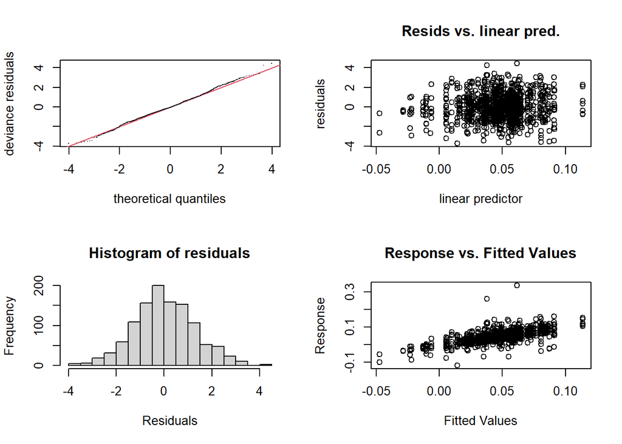

```
##
## Method: fREML   Optimizer: perf chol
## $grad
## [1] -1.157900e-05 -3.646650e-07 -1.100880e-05  1.176605e-05
##
## $hess
##               [,1]         [,2]          [,3]          [,4]
## [1,]  1.157883e-05 3.575689e-07 -5.910594e-11 -1.068258e-05
## [2,]  3.575689e-07 4.174358e-02  6.590658e-07  7.497050e-02
## [3,] -5.910594e-11 6.590658e-07  1.100926e-05  6.632602e-05
## [4,] -1.068258e-05 7.497050e-02  6.632602e-05  4.539222e+01
##
## Model rank =  210 / 210
##
## Basis dimension (k) checking results. Low p-value (k-index<1) may
## indicate that k is too low, especially if edf is close to k'.
##
##                               k'      edf k-index p-value
## s(age)                  9.00e+00 1.00e+00    0.96    0.11
## s(age):group.ordtypical 9.00e+00 1.32e+00    0.96    0.08 .
## s(subj)                 4.70e+01 2.20e-04      NA      NA
## s(cluster,subj)         1.41e+02 1.18e+02      NA      NA
## ---
## Signif. codes:  0 '***' 0.001 '**' 0.01 '*' 0.05 '.' 0.1 ' ' 1
```

```r
gam.check(mFinal)
```

Looks excellent.

Model criticism, trimming:

```r
df.nospr3 <- df.nospr[abs(scale(resid(mFinal))) < 2.5, ] # trim model
(1 - (nrow(df.nospr3))/nrow(df.nospr)) * 100
```

```
## [1] 1.405975
```

1.4% removed.

Refit:

```r
summary(mFinal_trim <- bam(time.lag.norm ~ group.ord + cluster + s(age) + s(age, by = group.ord) + s(subj,bs='re') + s(subj, cluster, bs ="re"), data=df.nospr3, family = "scat", discrete = T, nthreads = 2))
```

```
##
## Family: Scaled t(3,0.013)
## Link function: identity
##
## Formula:
## time.lag.norm ~ group.ord + cluster + s(age) + s(age, by = group.ord) +
##     s(subj, bs = "re") + s(subj, cluster, bs = "re")
##
## Parametric coefficients:
##                   Estimate Std. Error t value Pr(>|t|)
## (Intercept)       0.062034   0.004003  15.495  < 2e-16 ***
## group.ordtypical -0.002866   0.004172  -0.687  0.49226
## clustersp        -0.014451   0.004704  -3.072  0.00218 **
## clustersx        -0.031482   0.005007  -6.287 4.82e-10 ***
## ---
## Signif. codes:  0 '***' 0.001 '**' 0.01 '*' 0.05 '.' 0.1 ' ' 1
##
## Approximate significance of smooth terms:
##                             edf Ref.df      F p-value
## s(age)                    1.000   1.00  0.209  0.6478
## s(age):group.ordtypical   1.537   1.55  3.741  0.0205 *
## s(subj)                   1.602  43.00  0.408  0.7239
## s(cluster,subj)         115.145 130.00 12.640  <2e-16 ***
## ---
## Signif. codes:  0 '***' 0.001 '**' 0.01 '*' 0.05 '.' 0.1 ' ' 1
##
## Rank: 209/210
## R-sq.(adj) =  0.536   Deviance explained = 44.9%
## fREML = 2159.8  Scale est. = 1         n = 1122
```

Same pattern.

Visualize:

```
## Summary:
##  * group.ord : factor; set to the value(s): PD, typical.
##  * cluster : factor; set to the value(s): sp. (Might be canceled as random effect, check below.)
##  * age : numeric predictor; with 30 values ranging from 52.000000 to 81.000000.
##  * subj : factor; set to the value(s): CTRL21. (Might be canceled as random effect, check below.)
##  * NOTE : The following random effects columns are canceled: s(subj),s(cluster,subj)
##
```

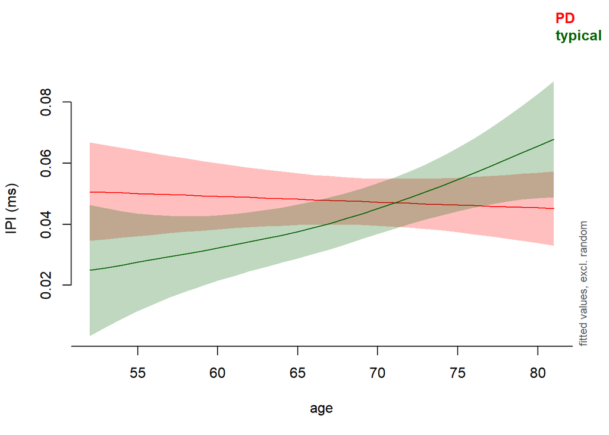

```r
plot_smooth(mFinal_trim, view = "age", plot_all = "group.ord", ylab = "IPI (ms)", rm.ranef=TRUE, col=c("red", "darkgreen"),rug = F)
```

# 5 Latex table

Latex table function:

```r
gamtabs2 <- function (model, caption = " ", label = "tab.gam",
    pnames = NA, snames = NA, ptab = NA, stab = NA, ...)
{
    if (!requireNamespace("xtable", quietly = TRUE)) {
        stop("Package 'xtable' needed for this function to work. Please install it.",
            call. = FALSE)
    }
    sum.gam <- model
    if (!inherits(model, "summary.gam")) {
        sum.gam <- summary(model)
    }
    if (is.na(ptab[1])) {
        ptab = as.data.frame(sum.gam$p.table, stringsAsFactors = FALSE)
    }
    if (is.na(stab[1])) {
        stab = as.data.frame(sum.gam$s.table, stringsAsFactors = FALSE)
    }
    if (!is.na(pnames[1])) {
        rownames(ptab) = pnames
    }
    if (!is.na(snames[1])) {
        rownames(stab) = snames
    }
    colnames(ptab)[4] = "p-value"
    colnames(ptab)[3] = "t-value"
    ptab.cnames = colnames(ptab)
    stab.cnames = colnames(stab)
    stab.cnames[3] = "F-value"
    colnames(ptab) = c("A", "B", "C", "D")
    if (ncol(stab) != 0) {
        colnames(stab) = colnames(ptab)
    }
    tab = rbind(ptab, stab)
    colnames(tab) = ptab.cnames
    tab = round(tab, 4)
    m = data.frame(matrix(0, nrow(tab), ncol(tab)), stringsAsFactors = FALSE)
    for (i in 1:nrow(tab)) {
        for (j in 1:4) {
            if ((j == 4) & (tab[i, j] < 1e-03)) {
                m[i, j] = "< 0.001"
            }
            else {
                m[i, j] = sprintf("%3.3f", tab[i, j])
            }
        }
    }
    colnames(m) = colnames(tab)
    rownames(m) = rownames(tab)
    tab = m
    tab2 = rbind(c(ptab.cnames), tab[1:nrow(ptab), ])
    if (nrow(stab) > 0) {
        tab2 = rbind(tab2, c(stab.cnames), tab[(nrow(ptab) +
            1):nrow(tab), ])
    }
    if (nrow(stab)) {
        rownames(tab2)[(nrow(ptab) + 2)] = "B. smooth terms"
    }
    rownames(tab2)[1] = "A. parametric coefficients"
    for (i in 1:nrow(tab2)) {
        if (tab2[i, 4] == "0")
            tab2[i, 4] = "< 0.0001"
        if (length(grep("\\.", tab2[i, 2])) == 0)
            tab2[i, 2] = paste(tab2[i, 2], ".0000", sep = "")
    }
    print(xtable::xtable(tab2, caption = caption, label = label,
        align = "lrrrr"), include.colnames = FALSE, hline.after = c(0,
        (nrow(ptab) + 1), nrow(tab2)), ...)
}
```

Latex table:

```r
options(xtable.comment = FALSE)
gamtabs2(mFinal_trim)
```

```
## \begin{table}[ht]
## \centering
## \begin{tabular}{lrrrr}
##    \hline
## A. parametric coefficients & Estimate & Std. Error & t-value & p-value \\
##   (Intercept) & 0.062 & 0.004 & 15.495 & $<$ 0.001 \\
##   group.ordtypical & -0.003 & 0.004 & -0.687 & 0.492 \\
##   clustersp & -0.014 & 0.005 & -3.072 & 0.002 \\
##   clustersx & -0.032 & 0.005 & -6.287 & $<$ 0.001 \\
##    \hline
## B. smooth terms & edf & Ref.df & F-value & p-value \\
##   s(age) & 1.000 & 1.000 & 0.209 & 0.648 \\
##   s(age):group.ordtypical & 1.537 & 1.550 & 3.741 & 0.020 \\
##   s(subj) & 1.602 & 43.000 & 0.408 & 0.724 \\
##   s(cluster,subj) & 115.145 & 130.000 & 12.640 & $<$ 0.001 \\
##    \hline
## \end{tabular}
## \caption{ }
## \label{tab.gam}
## \end{table}
```